# Lab 1, parte 2: respostas individuais

José Ivan Silva da Cruz Júnior

```r
atividade = read_projectdata()
```

1. Quais os partidos onde seus parlamentares mais e menos tuítam, por proporção?

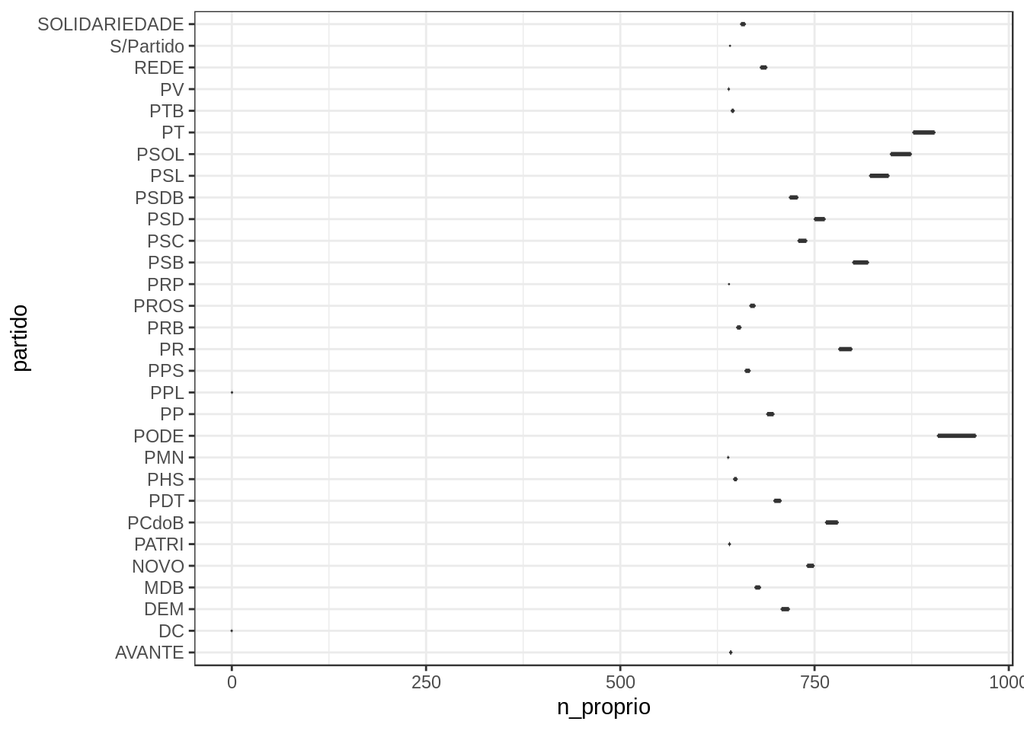

```r
  atividade %>% ggplot(aes(x = n_proprio, y = partido)) %>% + geom_boxplot()
```

Resposta antes da análise dos dados: - os que mais tuítam: PT e PSL por sua relevância nas casas e pela maior polarização existente em torno dos partidos. - os que menos tuítam: Rede e PHS por serem partidos com menos polarização.

1.1) Dos 5 partidos onde seus parlamentares mais tuítam tuítes próprios, quais os que mais e menos retuíta? Pela análise anterior vemos que os 5 partidos onde seus paralemnetraes mais tuítam tuítes próprios são o PODEMOS, PT, PSOL, PSL e PSB.

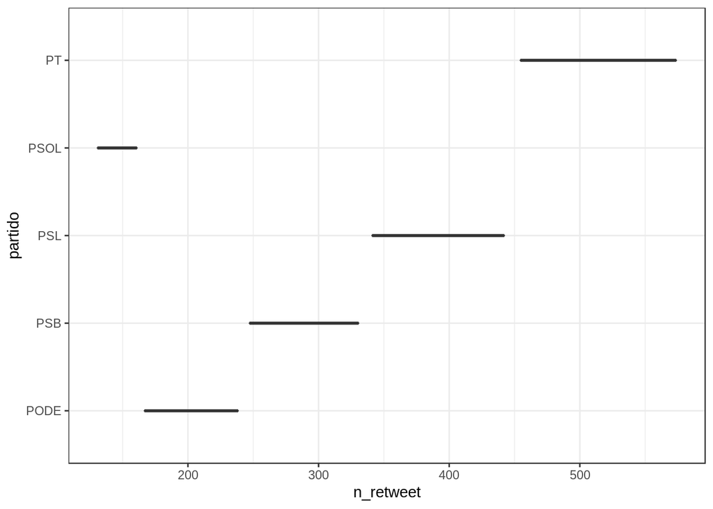

```r
atividade %>% filter(partido == "PODE" | partido == "PT" | partido == "PSOL" | partido == "PSL" | partido == "PSB") %>% ggplot(aes(x = n_retweet, y = partido)) + geom_boxplot()
```

Dos partidos onde seus parlamentares mais tuítam tuítes próprios o que mais e menos retuítam é o PT e o PSOL, respectivamente. A ordem ficou a seguinte: PT, PSL, PSB, PODEMOS e PSOL.

2. Quais as UF onde seus parlamentares mais e menos tuítam (tuítes próprios)?

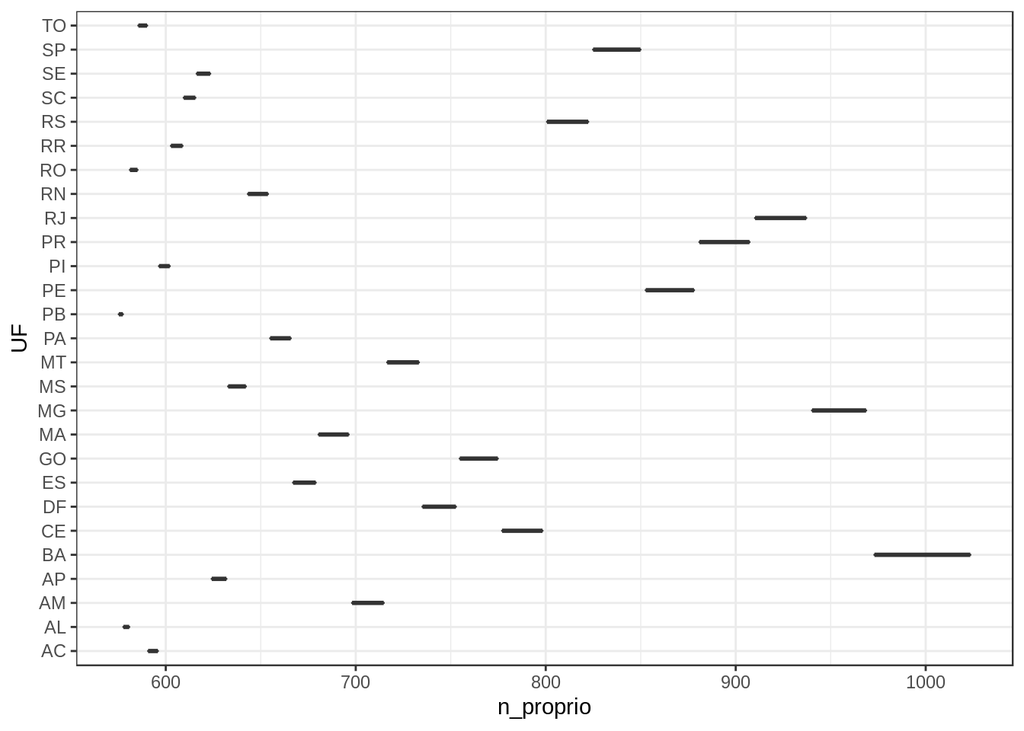

```r
atividade %>% ggplot(aes(x = n_proprio, y = UF)) + geom_boxplot()
```

Resposta antes da análise dos dados: - UF que mais tuítam: São Paulo e Rio Grande do Sul, por serem estados onde suas populações possuem mais acesso a internet. - UF que menos tuítam: Piauí e Maranhão, por serem estados onde suas populações possuem menos acesso a internet.

Resposta depois da análise dos dados: Os estados brasileiros onde seus parlamentares mais tuítam tuítes próprios são a Bahia e Minas Gerais, respectivamente. São estados que figuram entre os quatro maiores colégios eleitorais do país, sendo assim, cada parlamentar precisará de uma razoável quantidade de votos para se eleger e o twitter acaba sendo uma eficaz ferramenta para falar com um grande eleitorado. Em contrapartida, os estados onde seus parlamentares menos tuítam tuítes próprios são a Paraíba e Alagoas, respectivamente. Estados esses que são colégios eleitorais pequenos e da região que menos possui acesso a internet (apenas 37,2% da população). Os parlamentares devem se utilizar de outros meios para se comunicar com seus eleitores.

2.1) Dos estados onde seus parlamentares mais tuítam, qual o que mais e menos retuíta? Pela análise anterior vemos que os 5 estados onde seus parlamentares mais tupitam tuítes prórios são Bahia, Minas Gerais, Rio de Janeiro, Paraná e Pernambuco.

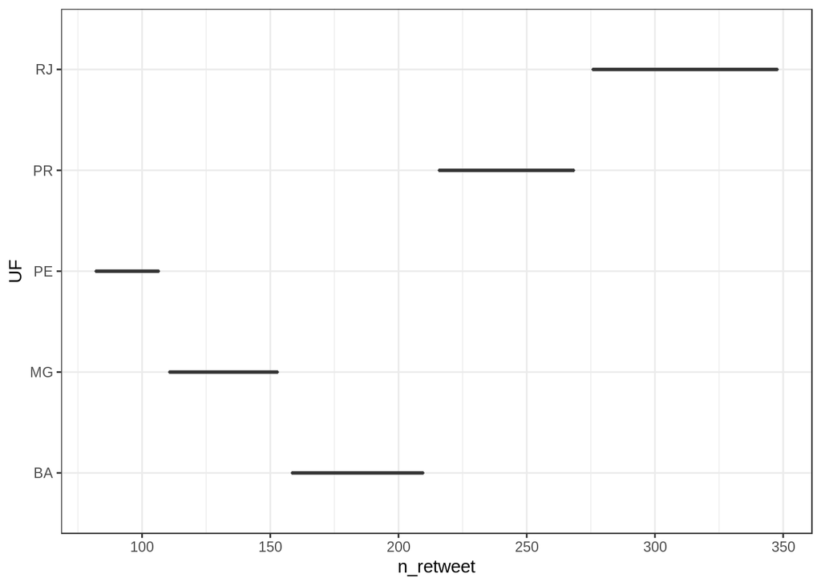

```r
atividade %>% filter(UF == "BA" | UF == "MG" | UF == "RJ" | UF == "PR" | UF == "PE") %>% ggplot(aes(x = n_retweet, y = UF)) + geom_boxplot()
```

Podemos observar que, dentre os estados citados, o que mais e menos retuíta é o Rio de Janeiro e Pernambuco, respectivamente. A ordem ficou assim: Rio de Janeiro, Paraná, Bahia, Minas Gerais e Pernambuco.